# IMDB Sentiment Analysis (Warm-Start From Pretrained Embedding)

Biostat 203B

Author

Dr. Hua Zhou @ UCLA

Published

February 28, 2024

## 1 Setup

Display system information for reproducibility.

**Python**

```python
import IPython
print(IPython.sys_info())
```

```
{'commit_hash': '8b1204b6c',
 'commit_source': 'installation',
 'default_encoding': 'utf-8',
 'ipython_path': '/opt/venv/lib/python3.10/site-packages/IPython',
 'ipython_version': '8.21.0',
 'os_name': 'posix',
 'platform': 'Linux-6.6.12-linuxkit-aarch64-with-glibc2.35',
 'sys_executable': '/opt/venv/bin/python',
 'sys_platform': 'linux',
 'sys_version': '3.10.12 (main, Nov 20 2023, 15:14:05) [GCC 11.4.0]'}
```

**R**

Load libraries.

**Python**

```python
# Plotting tool
import matplotlib.pyplot as plt
# Load Tensorflow and Keras
import tensorflow as tf
from tensorflow import keras
from tensorflow.keras import layers
import tensorflow_hub as hub
```

**R**

```r
library(keras)
library(tfhub)
```

Source: https://tensorflow.rstudio.com/tutorials/keras/text_classification_with_hub

## 2 Prepare data

Different from earlier experiment of fitting LSTM on IMDB data, we will start from the original raw text of IMDB reviews.

We download the IMDB dataset from a static url (if it’s not already in the cache):

**R**

```r
if (dir.exists("aclImdb/"))
  unlink("aclImdb/", recursive = TRUE)
url <- "https://ai.stanford.edu/~amaas/data/sentiment/aclImdb_v1.tar.gz"
dataset <- get_file(
  "aclImdb_v1",
  url,
  untar = TRUE,
  cache_dir = '.',
  cache_subdir = ''
)
```

```
Downloading data from https://ai.stanford.edu/~amaas/data/sentiment/aclImdb_v1.tar.gz
```

```r
unlink("aclImdb/train/unsup/", recursive = TRUE)
```

We can then create a TensorFlow dataset from the directory structure using the `text_dataset_from_directory` function:

**Python**

```python
batch_size = 512
seed = 425

train_data = keras.utils.text_dataset_from_directory(
  'aclImdb/train',
  batch_size = batch_size,
  validation_split = 0.2,
  subset = 'training',
  seed = seed
)
```

```
Found 25000 files belonging to 2 classes.
Using 20000 files for training.
```

```python
validation_data = keras.utils.text_dataset_from_directory(
  'aclImdb/train',
  batch_size = batch_size,
  validation_split = 0.2,
  subset = 'validation',
  seed = seed
)
```

```
Found 25000 files belonging to 2 classes.
Using 5000 files for validation.
```

```python
test_data = keras.utils.text_dataset_from_directory(
  'aclImdb/test',
  batch_size = batch_size
)
```

```
Found 25000 files belonging to 2 classes.
```

**R**

```r
batch_size <- 512
seed <- 425

train_data <- text_dataset_from_directory(
  'aclImdb/train',
  batch_size = batch_size,
  validation_split = 0.2,
  subset = 'training',
  seed = seed
)
```

```
Found 25000 files belonging to 2 classes.
Using 20000 files for training.
```

```r
validation_data <- text_dataset_from_directory(
  'aclImdb/train',
  batch_size = batch_size,
  validation_split = 0.2,
  subset = 'validation',
  seed = seed
)
```

```
Found 25000 files belonging to 2 classes.
Using 5000 files for validation.
```

```r
test_data <- text_dataset_from_directory(
  'aclImdb/test',
  batch_size = batch_size
)
```

```
Found 25000 files belonging to 2 classes.
```

Let’s take a moment to understand the format of the data. Each example is a sentence representing the movie review and a corresponding label. The sentence is not preprocessed in any way. The label is an integer value of either 0 or 1, where 0 is a negative review, and 1 is a positive review.

**Python**

```python
batch = list(train_data.as_numpy_iterator())[0]
batch[0][0]
```

```
b"Let me start out by saying I'm a big Carrey fan. Although I'll admit I haven't seen all of his movies *cough*the magestic*cough*. Bruce Almighty was enjoyable. None of the other reviews have really gone into how cheesy it gets towards the end, I dont know what the writers were thinking. Somehow I …
```

```python
batch[1][0:9]
```

```
array([1, 1, 1, 0, 0, 1, 0, 0, 0], dtype=int32)
```

**R**

```r
batch <- train_data %>%
  reticulate::as_iterator() %>%
  reticulate::iter_next()

batch[[1]][1]
```

```
tf.Tensor(b"Let me start out by saying I'm a big Carrey fan. Although I'll admit I haven't seen all of his movies *cough*the magestic*cough*. Bruce Almighty was enjoyable. None of the other reviews have really gone into how cheesy it gets towards the end, I dont know what the writers were thinking. …
```

Let’s also print the first 10 labels.

```r
batch[[2]][1:10]
```

```
tf.Tensor([1 1 1 0 0 1 0 0 0 0], shape=(10), dtype=int32)
```

## 3 Build model

Let’s first create a Keras layer that uses a TensorFlow Hub model to embed the sentences, and try it out on a couple of input examples. Note that no matter the length of the input text, the output shape of the embeddings is: `(num_examples, embedding_dimension)`.

**Python**

```python
embedding = "https://tfhub.dev/google/nnlm-en-dim50/2"
hub_layer = hub.KerasLayer(
  handle = embedding,
  # Enable fine-tuning (takes longer)
  trainable = True
  )
# Embed the first training texts
hub_layer(batch[0][0:1])
```

```
<tf.Tensor: shape=(1, 50), dtype=float32, numpy=
array([[ 0.76370066,  0.183997  , -0.12718768,  0.70335877,  0.07327911,
        -0.03899736,  0.10226654, -0.30235237, -0.50765055,  0.62317777,
         0.22796501, -0.09297381, -0.1462293 ,  0.20359744, -0.50289273,
         0.12905747, -0.46563283,  0.46837053,  0.3183409 , -0.53685   ,
         0.02151133, -0.40384126,  0.18346405,  0.21639028, -0.3739372 ,
         0.17969884, -1.0825881 , -0.08053909,  0.5606583 , -0.32753116,
        -0.7381755 ,  0.07553624,  0.28268006, -0.14106293, -0.40518084,
         0.27209735,  0.4923586 , -0.09804886,  0.2137844 , -0.45998612,
         0.289826  ,  0.12571187, -0.26875192,  0.02086616, -0.43353546,
        -0.11499331, -0.6014056 , -0.2741146 ,  0.04519763, -0.06563535]],
      dtype=float32)>
```

**R**

```r
embedding <- "https://tfhub.dev/google/nnlm-en-dim50/2"
hub_layer <- tfhub::layer_hub(
  handle = embedding,
  # Enable fine-tuning (takes longer)
  trainable = TRUE
  )
# Embed the first training texts
hub_layer(batch[[1]][1:2])
```

```
tf.Tensor(
[[ 0.76370066  0.183997   -0.12718768  0.70335877  0.07327911 -0.03899736
   0.10226654 -0.30235237 -0.50765055  0.62317777  0.22796501 -0.09297381
  -0.1462293   0.20359744 -0.50289273  0.12905747 -0.46563283  0.46837053
   0.3183409  -0.53685     0.02151133 -0.40384126  0.18346405  0.21639028
  -0.3739372   0.17969884 -1.0825881  -0.08053909  0.5606583  -0.32753116
  -0.7381755   0.07553624  0.28268006 -0.14106293 -0.40518084  0.27209735
   0.4923586  -0.09804886  0.2137844  -0.45998612  0.289826    0.12571187
  -0.26875192  0.02086616 -0.43353546 -0.11499331 -0.6014056  -0.2741146
   0.04519763 -0.06563535]
 [ 0.9949969   0.5141704   0.16449574  0.8084587  -0.20159443 -0.50888604
   0.38217273 -0.12473521 -1.0824962   0.7963115  -0.5053254   0.13061531
   0.02384013 -0.05730984 -0.53146046 -0.40029854 -0.78000605 -0.22182897
   0.48937032 -1.3286033   0.06303684 -0.16473001  1.3556808  -0.23764718
  -0.49831617  0.63716036 -1.8083394   0.09699536  0.24990597 -1.0124916
  -0.5400294   0.5142796   1.0795236  -0.64328635 -0.76760125  0.46185046
   0.34145948 -0.41720492  0.38070628 -1.0945162  -0.12662072  0.37232855
  -0.5240889   0.7304352  -0.21560599 -0.26014465 -0.54552066 -1.1023974
   0.16730602 -0.00775222]], shape=(2, 50), dtype=float32)
```

Let’s now build and compile the full model:

**Python**

```python
model = keras.Sequential([
  hub_layer,
  layers.Dense(units = 16, activation = 'relu'),
  layers.Dense(units = 1, activation = 'sigmoid')
]
)
```

```python
model.compile(
  optimizer = 'adam',
  loss = "binary_crossentropy",
  metrics = 'accuracy'
)
```

**R**

```r
model <- keras_model_sequential() %>%
  hub_layer() %>%
  layer_dense(16, activation = 'relu') %>%
  layer_dense(1)
```

Compile model:

```r
model %>% compile(
  optimizer = 'adam',
  loss = loss_binary_crossentropy(from_logits = TRUE),
  metrics = 'accuracy'
)
```

## 4 Training

**Python**

```python
history = model.fit(
  train_data,
  epochs = 10,
  validation_data = validation_data,
  verbose = 2
)
```

```
40/40 - 5s - loss: 0.6486 - accuracy: 0.6365 - val_loss: 0.5793 - val_accuracy: 0.7404 - 5s/epoch - 116ms/step
40/40 - 4s - loss: 0.5020 - accuracy: 0.7958 - val_loss: 0.4466 - val_accuracy: 0.8248 - 4s/epoch - 103ms/step
40/40 - 4s - loss: 0.3539 - accuracy: 0.8721 - val_loss: 0.3525 - val_accuracy: 0.8576 - 4s/epoch - 102ms/step
40/40 - 4s - loss: 0.2502 - accuracy: 0.9140 - val_loss: 0.3130 - val_accuracy: 0.8718 - 4s/epoch - 101ms/step
40/40 - 4s - loss: 0.1830 - accuracy: 0.9411 - val_loss: 0.2950 - val_accuracy: 0.8780 - 4s/epoch - 102ms/step
40/40 - 4s - loss: 0.1335 - accuracy: 0.9617 - val_loss: 0.2912 - val_accuracy: 0.8828 - 4s/epoch - 101ms/step
40/40 - 4s - loss: 0.0964 - accuracy: 0.9762 - val_loss: 0.2978 - val_accuracy: 0.8796 - 4s/epoch - 102ms/step
40/40 - 4s - loss: 0.0701 - accuracy: 0.9862 - val_loss: 0.3121 - val_accuracy: 0.8772 - 4s/epoch - 103ms/step
40/40 - 4s - loss: 0.0503 - accuracy: 0.9919 - val_loss: 0.3200 - val_accuracy: 0.8768 - 4s/epoch - 103ms/step
40/40 - 4s - loss: 0.0363 - accuracy: 0.9962 - val_loss: 0.3346 - val_accuracy: 0.8758 - 4s/epoch - 102ms/step
```

```python
model.summary()
```

```
Model: "sequential"
_________________________________________________________________
 Layer (type)                Output Shape              Param #
=================================================================
 keras_layer (KerasLayer)    (None, 50)                48190600

 dense (Dense)               (None, 16)                816

 dense_1 (Dense)             (None, 1)                 17

=================================================================
Total params: 48191433 (183.84 MB)
Trainable params: 48191433 (183.84 MB)
Non-trainable params: 0 (0.00 Byte)
_________________________________________________________________
```

Visualize training process:

```python
plt.figure()
plt.ylabel("Loss (training and validation)")
plt.xlabel("Training Epoches")
plt.ylim([0, 1])
```

```
(0.0, 1.0)
```

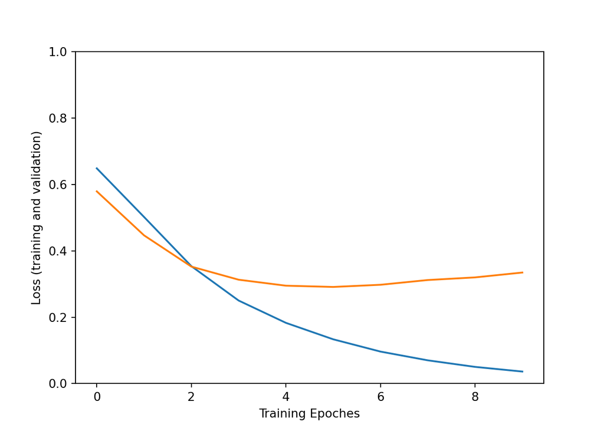

```python
plt.plot(history.history["loss"])
plt.plot(history.history["val_loss"])
plt.show()
```

```python
plt.figure()
plt.ylabel("Accuracy (training and validation)")
plt.xlabel("Training Epoches")
plt.ylim([0, 1])
```

```
(0.0, 1.0)
```

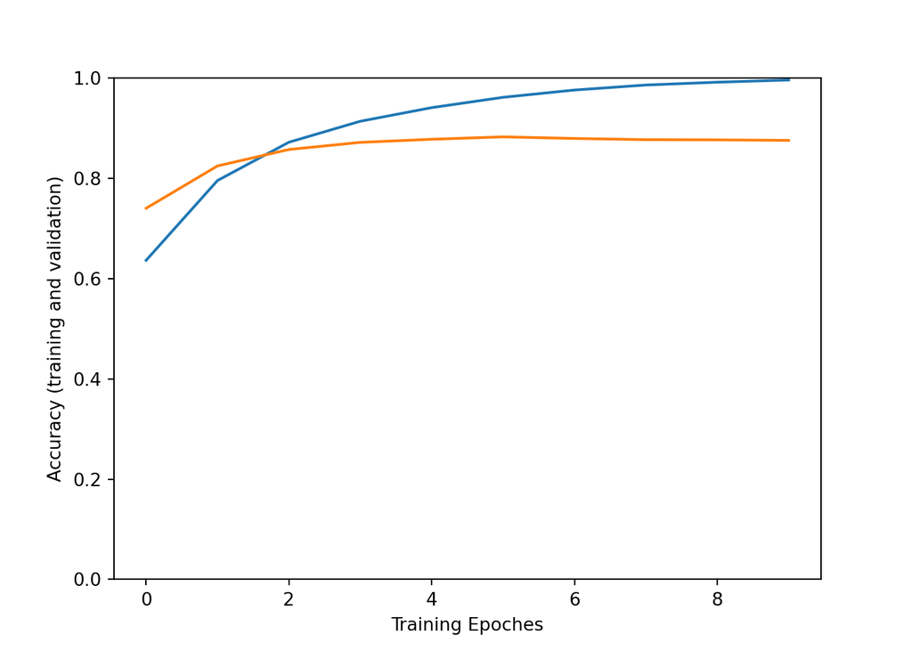

```python
plt.plot(history.history["accuracy"])
plt.plot(history.history["val_accuracy"])
plt.show()
```

**R**

```r
system.time({
history <- model %>% fit(
  train_data,
  epochs = 10,
  validation_data = validation_data,
  verbose = 2
)
})
```

```
40/40 - 4s - loss: 0.6355 - accuracy: 0.5730 - val_loss: 0.5708 - val_accuracy: 0.6666 - 4s/epoch - 109ms/step
40/40 - 4s - loss: 0.4922 - accuracy: 0.7526 - val_loss: 0.4346 - val_accuracy: 0.8016 - 4s/epoch - 102ms/step
40/40 - 4s - loss: 0.3411 - accuracy: 0.8591 - val_loss: 0.3436 - val_accuracy: 0.8518 - 4s/epoch - 103ms/step
40/40 - 4s - loss: 0.2422 - accuracy: 0.9082 - val_loss: 0.3091 - val_accuracy: 0.8584 - 4s/epoch - 104ms/step
40/40 - 4s - loss: 0.1784 - accuracy: 0.9370 - val_loss: 0.2940 - val_accuracy: 0.8700 - 4s/epoch - 102ms/step
40/40 - 4s - loss: 0.1317 - accuracy: 0.9579 - val_loss: 0.2908 - val_accuracy: 0.8736 - 4s/epoch - 101ms/step
40/40 - 4s - loss: 0.0961 - accuracy: 0.9744 - val_loss: 0.2993 - val_accuracy: 0.8778 - 4s/epoch - 102ms/step
40/40 - 4s - loss: 0.0695 - accuracy: 0.9844 - val_loss: 0.3140 - val_accuracy: 0.8798 - 4s/epoch - 101ms/step
40/40 - 4s - loss: 0.0497 - accuracy: 0.9908 - val_loss: 0.3249 - val_accuracy: 0.8780 - 4s/epoch - 104ms/step
40/40 - 4s - loss: 0.0355 - accuracy: 0.9948 - val_loss: 0.3405 - val_accuracy: 0.8774 - 4s/epoch - 103ms/step
```

```
   user  system elapsed
169.269  38.564  41.263
```

```r
summary(model)
```

```
Model: "sequential_1"
________________________________________________________________________________
 Layer (type)                       Output Shape                    Param #
================================================================================
 keras_layer_1 (KerasLayer)         (None, 50)                      48190600
 dense_3 (Dense)                    (None, 16)                      816
 dense_2 (Dense)                    (None, 1)                       17
================================================================================
Total params: 48191433 (183.84 MB)
Trainable params: 48191433 (183.84 MB)
Non-trainable params: 0 (0.00 Byte)
________________________________________________________________________________
```

Visualize training process:

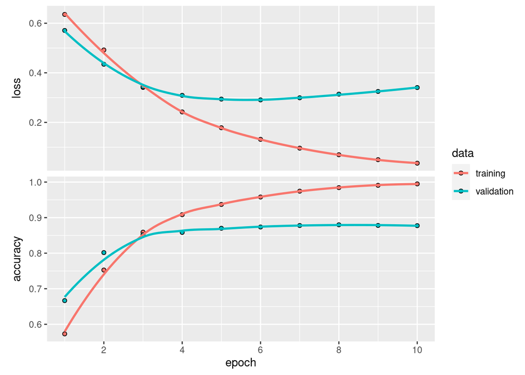

```r
plot(history)
```

## 5 Testing

**Python**

```python
results = model.evaluate(test_data, verbose = 2)
```

```
49/49 - 2s - loss: 0.3673 - accuracy: 0.8598 - 2s/epoch - 40ms/step
```

```python
results
```

```
[0.36734020709991455, 0.8597599864006042]
```

**R**

```r
results <- model %>% evaluate(test_data, verbose = 2)
```

```
49/49 - 2s - loss: 0.3775 - accuracy: 0.8544 - 2s/epoch - 40ms/step
```

```r
results
```

```
     loss  accuracy
0.3774581 0.8543600
```